# Are Planetterp Ratings Influenced By Grade Bias?

Samuel Miller

## Introduction

Planetterp (https://planetterp.com) is a website that allows University of Maryland students to rate and review their professors and courses, as well as display grade data for each course. Each semester, many students use these ratings to determine if they want to take a class with a certain professor. However, if these ratings are biased, students may not be making decisions that are well informed.

In this tutorial, we will explore the extent to which grades in a certain class affect its ratings.

## Project Setup

Here are all the libraries necessary for this project.

We will be working with pandas and numpy for data handling, seaborn for plotting (it is built off matplotlib and requires the import), requests to get the data, and scipy to analyze the data.

Here are some good introductions if you haven't worked with some of them before and want to have a good idea of how they function and what they can do:

- pandas: https://pandas.pydata.org/pandas-docs/stable/user_guide/10min.html
- requests: https://docs.python-requests.org/en/master/user/quickstart/
- seaborn: https://seaborn.pydata.org/introduction.html
- scipy: https://docs.scipy.org/doc/scipy/reference/tutorial/general.html

```python
import pandas as pd
import numpy as np
import matplotlib.pyplot as plt
import seaborn as sbn
import requests
from scipy import stats
```

## Gathering the Data

#### Gathering the Course Data

First we need to gather the course data.

We can obtain the data from plantterp's online API. You can see the proper usage of it here: https://api.planetterp.com. Basically, we append parameters onto the url to alter the data shown on the page.

We first need to send a get request to obtain the data. Planetterp has some restrictions here. The max limit per page for planetterp's api is 1000, so we need to iterate with offeset in order to get all of them. We will also collect all the reviews into a list, and concatenate with each iteration.

Further, the data is formatted as a JSON file, so we will use the .json() method of requests to make sure that the data structures are imported correctly into python as dicts and lists. If you would like to learn more about the structure of JSON files, DigitalOcean has a great explanation: https://www.digitalocean.com/community/tutorials/an-introduction-to-json.

In order to only take the data we are interested in from each review, we will use comprehensions in order to select from the list of keys. We are only taking what can be reasonably analyzed as numerical data - while possible, analysis of the other keys' data is a bit out of scope for this tutorial. If you are interested, you can check the API page for all the possible keys. If you would like an introduction to list & dictionary comprehensions and how they work when nested, netguru has a great walkthrough: https://www.netguru.com/codestories/python-list-comprehension-dictionary.

We then import the data to a pandas DataFrame. For an introduciton to pandas, visit the pandas docs user guide "10 minutes to pandas": https://pandas.pydata.org/pandas-docs/stable/user_guide/10min.html.

```python
data = []

i = 0
length = -1
while length != 0:
  courses = requests.get('https://api.planetterp.com/v1/courses?reviews=true&limit=1000&offset=' + str(i * 1000)).json() # send a get request and parse as json

  length = len(courses) # when the length is 0, there will be no more courses left, and the loop will break
  i += 1

  for course in courses:
    keys = ['rating', 'created', 'expected_grade', 'professor', 'course'] # from each review, we will only be taking this data
    data += [{key: review[key] for key in keys} for review in course['reviews']] # a dictionary comprehension nested inside a list comprehension

course_data = pd.DataFrame(data) # convert to dataframe
course_data.head() # display first five entries
```

|  | rating | created | expected_grade | professor | course |
| --- | --- | --- | --- | --- | --- |
| 0 | 5 | 2016-04-16T20:00:00 |  | Jonathan England | AASP100 |
| 1 | 5 | 2015-05-11T23:06:00 |  | Jonathan England | AASP100 |
| 2 | 4 | 2014-01-13T21:55:00 | C | Jonathan England | AASP100 |
| 3 | 5 | 2012-09-23T00:11:00 | A | Jonathan England | AASP100 |
| 4 | 5 | 2012-02-13T00:28:00 |  | Jonathan England | AASP100 |

Next, we have to clean up the data.

We first replace all the whitespace with NaN, drop all rows that include NaN, then reset the indices of the dataframe. This will remove rows with incomplete data.

Next, we will capitalize all the expected grades to standardize them.

After this, we remove all rows with expected grades other than the standard letters we will be using (by regex). This is to ensure that we are only working with the standard letter grades. For an overview of regular expressions, see the python docs howto: https://docs.python.org/3/howto/regex.html.

Also, we can create an additional clomun for department by using the string accessor and selecting the first four characters to get the department part of the course code. For a list of all departments (and proof that they are all 4 characters long), see the University of Maryland Schedule of Classes homepage: https://app.testudo.umd.edu/soc/.

We will also need to convert the letters to numbers for ease of analysis. Here, a dictionary is used. We have 2 lists and they are zipped together, then cast to a dict. A list comprehension is used to apply it to the whole column of the dataframe.

Lastly, the created times will be converted to datetime for ease of use later on. For an explanantion on datetime, check out the python docs: https://docs.python.org/3/library/datetime.html.

```python
courses_frame = course_data.replace(r'^\s*$', np.nan, regex = True) # replace whitespace with NaN
courses_frame = courses_frame.dropna() # drop all rows with NaN
courses_frame = courses_frame.reset_index(drop = True) # reset indices

courses_frame['expected_grade'] = courses_frame['expected_grade'].str.upper() # capitalize
courses_frame = courses_frame[courses_frame['expected_grade'].str.contains('^[A-D][+,-]?$|^F$', regex = True)] # drop rows with nonstandard expected grades

courses_frame['dept'] = courses_frame['course'].str[:4] # create department column

# convert letters to numbers (into a new column)
possible_grades = ['A+', 'A', 'A-', 'B+', 'B', 'B-', 'C+', 'C', 'C-', 'D+', 'D', 'D-', 'F']
possible_nums = list(range(13, 0, -1))
letter_to_grade = dict(zip(possible_grades, possible_nums))
courses_frame['exp_num_grade'] = [letter_to_grade[letter] for letter in courses_frame['expected_grade']]

courses_frame['created'] = pd.to_datetime(courses_frame['created']) # convert to datetime

courses_frame.head()
```

|  | rating | created | expected_grade | professor | course | dept | exp_num_grade |
| --- | --- | --- | --- | --- | --- | --- | --- |
| 0 | 4 | 2014-01-13 21:55:00 | C | Jonathan England | AASP100 | AASP | 6 |
| 1 | 5 | 2012-09-23 00:11:00 | A | Jonathan England | AASP100 | AASP | 12 |
| 2 | 4 | 2012-01-01 04:19:00 | A- | Jonathan England | AASP100 | AASP | 11 |
| 3 | 5 | 2009-12-16 20:38:00 | A | Jonathan England | AASP100 | AASP | 12 |
| 4 | 5 | 2008-04-10 00:53:00 | A | Jonathan England | AASP100 | AASP | 12 |

#### Gathering the Grade Data

Here, we obtain the real grade data for each using a similar process as before, except this time we are limiting the grades to only be from courses in the previous data frame - there is no point gathering data that we will only have to drop later on. (Since data was dropped earlier, it is likely that some courses were dropped entriely; plus, some courses may have no reviews, but some grade data).

Note: this code may a couple minutes to run due to the sheer volume of data available.

Note: we aren't using the offset parameter since each course and professor has far less than 1000 semesters. However, even if you tried, you would find that it is broken/unimplemented for the grade data (at the time of writing this).

```python
data = []
courses = np.unique(courses_frame['course'])

for course in courses:
  i = 0
  grades = requests.get('https://api.planetterp.com/v1/grades?limit=1000&course=' + course).json() # send a get request and parse as json

  for entry in grades:
    keys = ['course', 'professor', 'semester', 'A+', 'A', 'A-', 'B+', 'B', 'B-', 'C+', 'C', 'C-', 'D+', 'D', 'D-', 'F'] # from each review, we will only be taking this data
    data += [{key: entry[key] for key in keys}] # a dictionary comprehension

grades_data = pd.DataFrame(data)
grades_data.head()
```

|  | course | professor | semester | A+ | A | A- | B+ | B | B- | C+ | C | C- | D+ | D | D- | F |
| --- | --- | --- | --- | --- | --- | --- | --- | --- | --- | --- | --- | --- | --- | --- | --- | --- |
| 0 | AASP100 | Jason Nichols | 202008 | 1 | 9 | 7 | 8 | 4 | 0 | 1 | 1 | 0 | 0 | 0 | 0 | 2 |
| 1 | AASP100 | Jason Nichols | 202008 | 1 | 11 | 7 | 6 | 5 | 2 | 0 | 1 | 0 | 1 | 1 | 0 | 0 |
| 2 | AASP100 | Shane Walsh | 202008 | 5 | 12 | 15 | 2 | 0 | 0 | 0 | 0 | 0 | 0 | 0 | 0 | 0 |
| 3 | AASP100 | Shane Walsh | 202008 | 2 | 16 | 13 | 1 | 2 | 0 | 1 | 0 | 0 | 0 | 0 | 0 | 0 |
| 4 | AASP100 | Shane Walsh | 202008 | 0 | 15 | 16 | 4 | 0 | 0 | 0 | 0 | 0 | 0 | 0 | 0 | 0 |

Same as before, the grade data is wrangled. We first replace all the whitespace with NaN, drop all rows that include NaN, then reset the indices of the dataframe. Also, a dept column is added.

```python
grades_frame = grades_data.replace(r'^\s*$', np.nan, regex = True) # replace whitespace with NaN
grades_frame = grades_frame.dropna() # drop all rows with NaN
grades_frame = grades_frame.reset_index(drop=True) # reset indices

grades_frame['dept'] = grades_frame['course'].str[:4] # create department column

grades_frame.head()
```

|  | course | professor | semester | A+ | A | A- | B+ | B | B- | C+ | C | C- | D+ | D | D- | F | dept |
| --- | --- | --- | --- | --- | --- | --- | --- | --- | --- | --- | --- | --- | --- | --- | --- | --- | --- |
| 0 | AASP100 | Jason Nichols | 202008 | 1 | 9 | 7 | 8 | 4 | 0 | 1 | 1 | 0 | 0 | 0 | 0 | 2 | AASP |
| 1 | AASP100 | Jason Nichols | 202008 | 1 | 11 | 7 | 6 | 5 | 2 | 0 | 1 | 0 | 1 | 1 | 0 | 0 | AASP |
| 2 | AASP100 | Shane Walsh | 202008 | 5 | 12 | 15 | 2 | 0 | 0 | 0 | 0 | 0 | 0 | 0 | 0 | 0 | AASP |
| 3 | AASP100 | Shane Walsh | 202008 | 2 | 16 | 13 | 1 | 2 | 0 | 1 | 0 | 0 | 0 | 0 | 0 | 0 | AASP |
| 4 | AASP100 | Shane Walsh | 202008 | 0 | 15 | 16 | 4 | 0 | 0 | 0 | 0 | 0 | 0 | 0 | 0 | 0 | AASP |

#### Averaging and Combining the Data

In order to analyze grade data alongside the ratings, we can average out the data for each professor-course combination. Since a review can be written at any time, we have no good way of combining the date created data (for a review) with the semester data for grades, so we will average across them and drop the remaining (now redundant) columns.

Note that we will still use these columns when only analyzing expected grade and rating, so we are not done with them.

We will achieve this with pandas groupby() method. We will group the frame by course and professor, taking the average of the grades for analysis. For an in depth walkthrough of how to use this method, see Real Python's tutorial: https://realpython.com/pandas-groupby/.

```python
courses_avg_frame = courses_frame.copy() # copy the courses frame
courses_avg_frame = courses_avg_frame.groupby(['course', 'professor']).mean() # group by course and professor

courses_avg_frame.head()
```

| course | professor | rating | exp_num_grade |
| --- | --- | --- | --- |
| AASP100 | Jason Nichols | 2.545455 | 9.818182 |
|  | Jonathan England | 4.666667 | 10.833333 |
|  | Shane Walsh | 4.500000 | 11.000000 |
| AASP100H | Jonathan England | 5.000000 | 12.000000 |
| AASP101 | Gniesha Dinwiddie | 1.750000 | 9.250000 |

Next, we group and find the averages of the real grade data. We need to take a weighted average since now we need to average all the data across the letter frequency columns. For information on weigther avergaes, check out the wiki page: https://en.wikipedia.org/wiki/Weighted_arithmetic_mean.

```python
grades_avg_frame = grades_frame.copy() # copy the grades frame
grades_avg_frame = grades_avg_frame.groupby(['course', 'professor']).sum() # group by course and professor

s = grades_avg_frame.sum(axis = 1) # get the sum of teh frequencies for each row
for col in grades_avg_frame.columns:
  grades_avg_frame[col] *= letter_to_grade[col] / s # multiply the frequency by the weight of the grade, then divide by the sum of the frequencies

grades_avg_frame['grade'] = grades_avg_frame.sum(axis = 1) # sum the partials together into a new column
grades_avg_frame = grades_avg_frame[['grade']] # drop all but the new column

grades_avg_frame.head()
```

| course | professor | grade |
| --- | --- | --- |
| AASP100 | George Kintiba | 11.103448 |
|  | Jason Nichols | 9.471101 |
|  | Jonathan England | 9.425962 |
|  | Kameron Patterson | 11.545455 |
|  | Shane Walsh | 10.760479 |

Finally, we merge the 2 frames.

```python
avg_frame = courses_avg_frame.merge(grades_avg_frame, left_index = True, right_index = True) # merge the frames

avg_frame.head()
```

| course | professor | rating | exp_num_grade | grade |
| --- | --- | --- | --- | --- |
| AASP100 | Jason Nichols | 2.545455 | 9.818182 | 9.471101 |
|  | Jonathan England | 4.666667 | 10.833333 | 9.425962 |
|  | Shane Walsh | 4.500000 | 11.000000 | 10.760479 |
| AASP100H | Jonathan England | 5.000000 | 12.000000 | 11.187500 |
| AASP101 | Gniesha Dinwiddie | 1.750000 | 9.250000 | 9.701613 |

All the data is now prepared for analysis.

## Data Visualization and Initial Analysis

#### Course Data

First, let's visualize the courese data.

A simple scatterplot would not work - the data is so discretized, the data points would show up on top of each other. We can use a violinplot of the expected grade supplied for each rating.

If you would like to review it, here is the documentation for seaborn's violinplots: https://seaborn.pydata.org/generated/seaborn.violinplot.html.

Note: as per the translation of grades to numbers, 1 is F, ..., 13 is A+

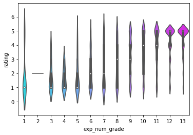

```python
sbn.violinplot(x = 'exp_num_grade', y = 'rating', palette = 'cool', data = courses_frame)
```

This visualization suggests that there is a correlation here, so a regression is in order.

Seaborn has a regplot method, which we will use. However, seaborn does not natively give the ability to print the formula and other stats. So we will use scipy to do so. Scipy's lingress() method gives the slope, intercept, correlation coefficient, p value, and standard error for a linear regression between two lists. For more information, see the docs: https://docs.scipy.org/doc/scipy/reference/generated/scipy.stats.linregress.html.

We can use the legend of the seaborn plot to display the statistics on the graph.

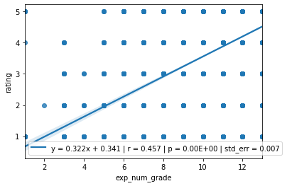

```python
slp, intr, r, p, std_err = stats.linregress(courses_frame['exp_num_grade'], courses_frame['rating'])
label = {'label': 'y = {0:.3f}x + {1:.3f} | r = {2:.3f} | p = {3:.2E} | std_err = {4:.3f}'.format(slp, intr, r, p, std_err)}
pl = sbn.regplot(x = 'exp_num_grade', y = 'rating', data = courses_frame, line_kws = label)
pl.legend()
```

Clearly, the scatterpoints do not reveal the data well (comapre to the violinplot above), but the regression line does show a correlation, and there is a correlation coefficient of 0.457, indicating at least a mild correlation.

#### Averaged Data

In terms of the grade data, we can visualize it better with a scatterplot now, since the data is averaged and no longer so discrete. It is worth remembering: we must use the averages for the grade data since the created date of a rating does not necessarily line up with semester the reviewer took the class. This does place significant limits on our analysis here since we cannot directly compare grades with ratings.

Additionally, we can add on the data for the average expected grades as a hue to see if the expected grades average lines up with the actual grade data.

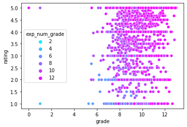

```python
sbn.scatterplot(x = 'grade', y = 'rating', hue = 'exp_num_grade', palette = 'cool', data = avg_frame)
```

Plotting this as a regplot, there seems to be little correlation between the average grade data and the reviews (r = 0.267).

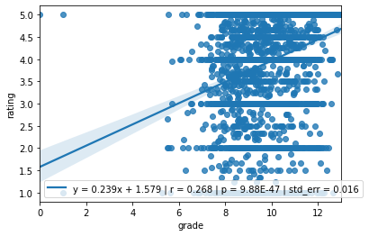

```python
slp, intr, r, p, std_err = stats.linregress(avg_frame['grade'], avg_frame['rating'])
label = {'label': 'y = {0:.3f}x + {1:.3f} | r = {2:.3f} | p = {3:.2E} | std_err = {4:.3f}'.format(slp, intr, r, p, std_err)}
pl = sbn.regplot(x = 'grade', y = 'rating', data = avg_frame, line_kws = label)
pl.legend()
```

As a sanity check, it is prudent to see of the grades people expect line up with and are reprsentative of the actual grade data, as this could heavily skew perceptions of the situation.

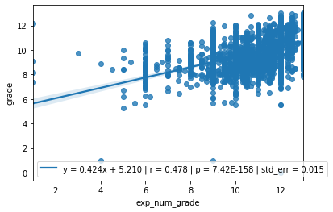

```python
slp, intr, r, p, std_err = stats.linregress(avg_frame['exp_num_grade'], avg_frame['grade'])
label = {'label': 'y = {0:.3f}x + {1:.3f} | r = {2:.3f} | p = {3:.2E} | std_err = {4:.3f}'.format(slp, intr, r, p, std_err)}
pl = sbn.regplot(x = 'exp_num_grade', y = 'grade', data = avg_frame, line_kws = label)
pl.legend()
```

This moderate correlation of 0.479 inidicates that directly comparing the averages of grade data and reviews might not be the best approach.

This may indicate that there is some sort of bias where reviewers of a given class do not well represent all students of that class.

Due to all this, for further analysis, we will only be looking at ratings vs expected grades for this part. We cannot be very confident in our comparisons between the actual grade data and ratings. This places significant limitations on our analysis.

## Analysis

Clearly, from the plots above there is some sort of moderate correlation between expected grade and rating for a specific class. The p value for the linear regression is so tiny (less than 1 * 10 ^ -150), so these results are definitely statistically significant. (For more information on interpreting regression coefficients, see here: https://blog.minitab.com/en/adventures-in-statistics-2/how-to-interpret-regression-analysis-results-p-values-and-coefficients).

An interesting thing that can be seen in the violinplot is that for those expecting a very high or very low grade, the rating distributions are very skewed. However, those who expected a grade that is in the middle did not cluster around an average rating - the rating categories were all equal. This may indicate that grade bias presents itself more for those who expect good and bad grades. Let's find out more.

We can take the expected grades that aren't high nor low. Let's define low grades as F through C- (1-5) and high grades as A- through A+ (11-13).

```python
courses_frame_middle = courses_frame[np.logical_and(courses_frame['exp_num_grade'] < 11, courses_frame['exp_num_grade'] > 5)]
```

We can now replot the violin plot in order to get a better look.

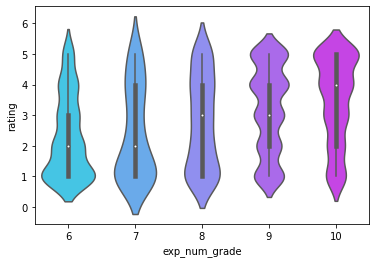

```python
sbn.violinplot(x = 'exp_num_grade', y = 'rating', palette = 'cool', data = courses_frame_middle)
```

There still looks to be some grade bias. It appears that a B (9) is the only expected grade that doesn't exhibit much skew (maybe B- (8) too). Further, it appears that for a B (and maybe a B-), expected grade has little to no impact on ratings, which may indicate that reviewers who are expecting a middle grade have less grade bias.

Lets take a look at the regression.

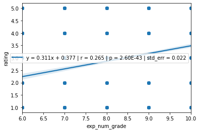

```python
slp, intr, r, p, std_err = stats.linregress(courses_frame_middle['exp_num_grade'], courses_frame_middle['rating'])
label = {'label': 'y = {0:.3f}x + {1:.3f} | r = {2:.3f} | p = {3:.2E} | std_err = {4:.3f}'.format(slp, intr, r, p, std_err)}
pl = sbn.regplot(x = 'exp_num_grade', y = 'rating', data = courses_frame_middle, line_kws = label)
pl.legend()
```

With a correlation coefficient of 0.264, it definitely seems like there is less grade bias amongst the middle expected grades. The p value is much higher than before, but still less than 1 * 10 ^ -40, so there is no doubt that there is still a statistically significant difference.

## Data Visualization & Analysis Part 2 - Across Time

We do have another variable available to us - time of review. In order for a more thorough analysis, we should see what affect time has on rating, and control for it when analyzing the correlation between expected grade and rating.

To start, let's make a violin plot, similar to earlier, and see if rating distributions change over time.

Our datetimes are exact to the second, but let's use only the year. This means that the plot may not be as exact, but we will be able to generally get an idea of what the data distributions looks like each year.

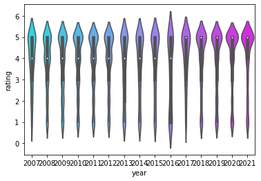

```python
courses_frame['year'] = courses_frame['created'].dt.year

sbn.violinplot(x = 'year', y = 'rating', palette = 'cool', data = courses_frame)
```

Surprisingly (to me, anyway), it seems that there is a slight change for reviews to skew higher as time went on.

Let's plot a regression to verify.

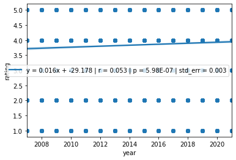

```python
slp, intr, r, p, std_err = stats.linregress(courses_frame['year'], courses_frame['rating'])
label = {'label': 'y = {0:.3f}x + {1:.3f} | r = {2:.3f} | p = {3:.2E} | std_err = {4:.3f}'.format(slp, intr, r, p, std_err)}
pl = sbn.regplot(x = 'year', y = 'rating', data = courses_frame, line_kws = label)
pl.legend()
```

With such a low correlation coefficient (0.053), it seems that time had a very weak effect. Let's see if this slight trend is mirrored in the expected grades that students have received over time.

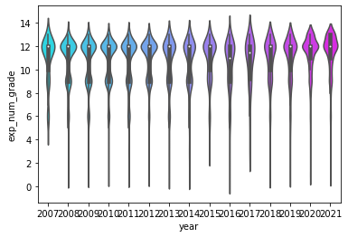

```python
sbn.violinplot(x = 'year', y = 'exp_num_grade', palette = 'cool', data = courses_frame)
```

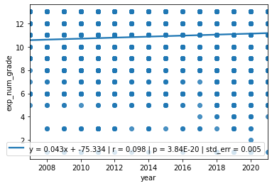

```python
slp, intr, r, p, std_err = stats.linregress(courses_frame['year'], courses_frame['exp_num_grade'])
label = {'label': 'y = {0:.3f}x + {1:.3f} | r = {2:.3f} | p = {3:.2E} | std_err = {4:.3f}'.format(slp, intr, r, p, std_err)}
pl = sbn.regplot(x = 'year', y = 'exp_num_grade', data = courses_frame, line_kws = label)
pl.legend()
```

And wouldn't you know?

As time went on, expected grades also increased a tiny bit.

Now it could be a coincidence that both grades and ratings were slightly higher as time went on, but it may not be. It is possible that over time, the slight expected grade inflation is the reason that the ratings increased a little.

## Data Visualization & Analysis Part 3 - Across Departments

Some departments may be more or less biased than others. Let's investigate.

We will separate the departments into 5 categories: those with a strong correlation (r > .8), a moderately strong correlation (.6 <= r < .8), a moderate correlation (.4 <= r < .6), a moderately weak correlation (.2 <= r < .4), and a weak correlation (r < .2).

Further restrictions that we should place for better analysis is ensuring the sample size for a department is above 20, so that we can be at least a little bit confident that the data has a smaller margin of error. Additionally, we should restrict the p value to lower than 0.05. This only includes results for which the probability of obtaining results at least as extreme as the observed results is less than 5% if expected grade does, in fact, have no effect on rating (for moderate to strong). For the weak and moderately weak cases, this only includes results for which the probability of obtaining results at least as extreme as the observed results is less than 5% if expected grade does, in fact, have little effect on rating (since we would expect a very weak correlation, but because the data is evenly distributed, not because the distributions for each grade are skewed, but with no gradual pattern with regards to the order of increasing/decreasing grades; otherwise we would not care too much about p value here at all).

Note: not much we can do about the warnings - scipy calculations have issues with some data from a couple of the departments. We will just ingnore these and only use departments that don't have issues (which is the overwhelming majority of them).

```python
# create dicts
strong_statistics = {}
mod_strong_statistics = {}
moderate_statistics = {}
mod_weak_statistics = {}
weak_statistics = {}

for dept in np.unique(courses_frame['dept']): # loop over each department
  courses_frame_dept = courses_frame[courses_frame['dept'] == dept] # restrict to one department

  slp, intr, r, p, std_err = stats.linregress(courses_frame_dept['exp_num_grade'], courses_frame_dept['rating']) # get linear regression data

  # filter into dictionaries and restrict by limitations
  if r < .2 and p < .05 and len(courses_frame_dept.index) > 20:
    weak_statistics[dept] = r, p
  elif r < .4 and r >= .2 and p < .05 and len(courses_frame_dept.index) > 20:
    mod_weak_statistics[dept] = r, p
  elif r >= .8 and p < .05 and len(courses_frame_dept.index) > 20:
    strong_statistics[dept] = r, p
  elif r < .8 and r >= .6 and p < .05 and len(courses_frame_dept.index) > 20:
    mod_strong_statistics[dept] = r, p
  elif r < .6 and r >= .4  and p < .05 and len(courses_frame_dept.index) > 20:
    moderate_statistics[dept] = r, p
```

[output not shown]

```python
print('r > .8:\n ', strong_statistics.keys())
print('r < .8 and r >= .6:\n ', mod_strong_statistics.keys())
print('r < .6 and r >= .4:\n ', moderate_statistics.keys())
print('r < .4 and r >= .2:\n ', mod_weak_statistics.keys())
print('r < .2:\n ', weak_statistics.keys())
```

```
r > .8:
  dict_keys([])
r < .8 and r >= .6:
  dict_keys(['ANSC', 'ARTH', 'COMM', 'ENSP', 'HESP', 'HIST', 'HLTH', 'KNES', 'WMST'])
r < .6 and r >= .4:
  dict_keys(['AASP', 'ARTT', 'ASTR', 'BCHM', 'BIOE', 'BMGT', 'BSCI', 'CCJS', 'CHEM', 'ECON', 'EDHD', 'ENCE', 'ENES', 'ENGL', 'ENME', 'ENST', 'GEOG', 'GEOL', 'INST', 'MATH', 'PHIL', 'PHYS', 'PSYC', 'SOCY', 'SPAN', 'STAT', 'UNIV'])
r < .4 and r >= .2:
  dict_keys(['ANTH', 'ARCH', 'CMSC', 'ENEE', 'GVPT', 'HONR', 'INAG', 'JOUR', 'LING', 'MUSC'])
r < .2:
  dict_keys([])
```

It is clear that some departments may be affected by grade bias more than others.

Let's visualize this on those departments with moderately strong correlations (there don't appear to be any with strong correlations and statistically significance).

Note: the join method is used to create a regular experession out of the list of departments that looks like 'AAAA|BBBB|CCCC'.

```python
courses_frame_strong = courses_frame[courses_frame['dept'].str.contains('|'.join(mod_strong_statistics.keys()))]

courses_frame_strong.head()
```

|  | rating | created | expected_grade | professor | course | dept | exp_num_grade | year |
| --- | --- | --- | --- | --- | --- | --- | --- | --- |
| 120 | 5 | 2020-05-16 23:01:35 | A | Sarah Balcom | ANSC101 | ANSC | 12 | 2020 |
| 121 | 4 | 2020-12-20 21:16:19 | A | Sarah Balcom | ANSC101 | ANSC | 12 | 2020 |
| 122 | 5 | 2020-05-16 23:03:20 | A- | Megan McLean | ANSC103 | ANSC | 11 | 2020 |
| 123 | 3 | 2020-12-09 05:08:25 | B+ | Megan McLean | ANSC103 | ANSC | 10 | 2020 |
| 124 | 5 | 2020-09-04 09:43:12 | B+ | Angela Black | ANSC204 | ANSC | 10 | 2020 |

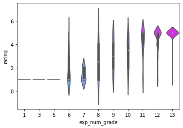

```python
sbn.violinplot(x = 'exp_num_grade', y = 'rating', palette = 'cool', data = courses_frame_strong)
```

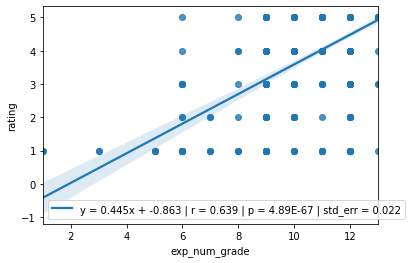

```python
slp, intr, r, p, std_err = stats.linregress(courses_frame_strong['exp_num_grade'], courses_frame_strong['rating'])
label = {'label': 'y = {0:.3f}x + {1:.3f} | r = {2:.3f} | p = {3:.2E} | std_err = {4:.3f}'.format(slp, intr, r, p, std_err)}
pl = sbn.regplot(x = 'exp_num_grade', y = 'rating', data = courses_frame_strong, line_kws = label)
pl.legend()
```

When only using data from ['ANSC', 'ARTH', 'COMM', 'ENSP', 'HESP', 'HIST', 'HLTH', 'KNES', 'WMST'], the correlation coefficient is a 0.639, with a p value under 1 * 10 ^ -65. We already know that they all individually have a statistically significant correlation with a coefficient greater than or equal to .6, so this isn't unexpected.

What may be unexpected is that is seems that it seems that nobody who took a class in any of these departments and expected lower than a C gave a rating above 1. That may be a potential source of bias.

Let's see if anything interesting presents itself in those that are weakly correlated.

```python
courses_frame_weak = courses_frame[courses_frame['dept'].str.contains('|'.join(mod_weak_statistics.keys()))]

courses_frame_weak.head()
```

|  | rating | created | expected_grade | professor | course | dept | exp_num_grade | year |
| --- | --- | --- | --- | --- | --- | --- | --- | --- |
| 149 | 5 | 2018-06-28 02:12:20 | A | Andrea Lopez | ANTH210 | ANTH | 12 | 2018 |
| 150 | 5 | 2019-01-25 03:53:25 | A+ | Miguel Vilar | ANTH222 | ANTH | 13 | 2019 |
| 151 | 2 | 2019-12-18 22:00:43 | B+ | L Jen Shaffer | ANTH222 | ANTH | 10 | 2019 |
| 152 | 5 | 2021-01-08 21:07:15 | B | Kevin Gibbons | ANTH222 | ANTH | 9 | 2021 |
| 153 | 5 | 2015-05-11 19:31:00 | A+ | Stephen Brighton | ANTH240 | ANTH | 13 | 2015 |

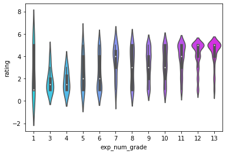

```python
sbn.violinplot(x = 'exp_num_grade', y = 'rating', palette = 'cool', data = courses_frame_weak)
```

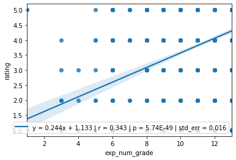

```python
slp, intr, r, p, std_err = stats.linregress(courses_frame_weak['exp_num_grade'], courses_frame_weak['rating'])
label = {'label': 'y = {0:.3f}x + {1:.3f} | r = {2:.3f} | p = {3:.2E} | std_err = {4:.3f}'.format(slp, intr, r, p, std_err)}
pl = sbn.regplot(x = 'exp_num_grade', y = 'rating', data = courses_frame_weak, line_kws = label)
pl.legend()
```

For the departments ['ANTH', 'ARCH', 'CMSC', 'ENEE', 'GVPT', 'HONR', 'INAG', 'JOUR', 'LING', 'MUSC'], the correlation coefficient of 0.343 and p value lower than 1 * 10 ^ -45 are again not unexpected since we already know that they all individually have a statistically significant correlation with a coefficient less than .4, so this isn't unexpected.

## Conclusions

The data show how expected grade does correlate with rating. But what does that mean?

For starters, we know that expected grade likely influences the rating, indicating that grade bias is prsent. But does that mean that reviews are a bad source of information? No! In fact, many students are actively looking for professors who give out higher grades. However, the data does suggest that if a student were to use rating data about courses as a means of guaging how well a professor teaches, they may be at least somewhat misinterpreting the reasons for why the ratings are what they are. Of course, being a better professor may mean that the grades in that class are higher - the students will learn better. So it might also be the other way around - that better professors will yield better grades. Whichever is the case, one should be cognizant that when using planetterp review data to choose which courses to take, the ratings are not independent of the expected grades.

Further, since there is a slight change over time, one should also be cognizant that newer ratings are probably slightly more accurate.

Lastly, some departments have ratings that seem to correlate with expected grade more than others, and one should definitely make sure to keep this in mind when using planetterp ratings to make a decision about taking a course in a given department.

## Further Reading

If you want to explore more about how biases can affect student evaluations, here are some interesting reads:

- Generally: https://www.insidehighered.com/news/2020/02/27/study-student-evaluations-teaching-are-deeply-flawed
- Grade Inflation as an Unintended Consequence of Teaching Evaluations: https://journals.sagepub.com/doi/abs/10.1177/1745691616650284
- Gender, Race, and Enthnicity Biases: https://www.cambridge.org/core/journals/ps-political-science-and-politics/article/exploring-bias-in-student-evaluations-gender-race-and-ethnicity/91670F6003965C5646680D314CF02FA4